Caret Realtors Leila Rayyan & Tanner Asmussen 03/05/2020

# Let Us Help You Find the Right Neighborhood in the Sacramento Area Using Caret

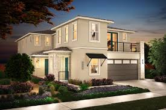

## First, Meet our Realtor Team!

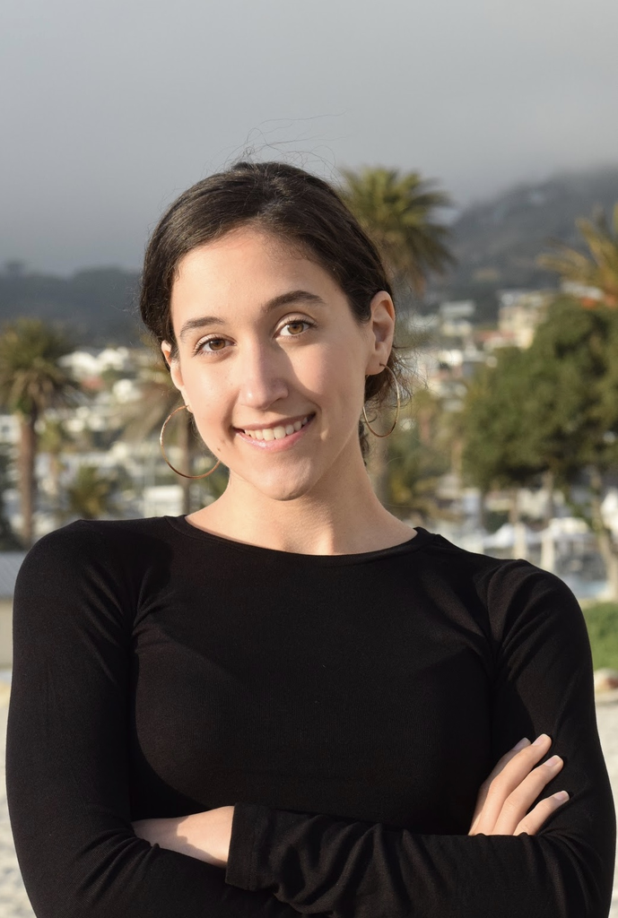

[figure not shown]

We have been diligently working with Caret to create the best model to predict the optimal neighborhood for you and your family based on your housing preferences! Let us walk you through what Caret is, and then we will show you the magic behind our top-notch predictive model!

#### *Voted best real estate predictive model of 2020!*

## Caret Package Overview

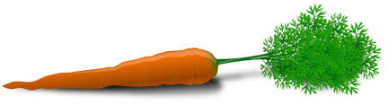

The **C**lassification **A**nd **RE**gression **T**raining package, known colloquially as **‘CARET’**, is a swiss army knife toolset for all things Machine Learning. The package contains a number of streamlining functions for data splitting, pre-processing, feature selection, model tuning using resampling, and variable importance estimation. While there exists no shortage of machine learning programs and functions throughout the codeverse, caret is unique in its uniform interface of these functions as simplification of common ML tasks. To that end, caret streamlines the start-up and usage process by limiting load-in requirements with respect to the number of “suggested” packages that are integral to any ML package iteration.

### History of Caret

Caret was first published in 2007 by Max Kuhn, who has continually updated to the present. Currently a Lead Software Engineer with RStudio, Kuhn created the package while he was with the R&D department at Pfizer Global. The intention of the package, in his words, were:

- To eliminate syntactical differences between many of the functions for building and predicting models;
- To develop a set of semi-automated, reasonable approaches for optimizing the values of the tuning parameters for many of these models; and
- To create a package that can easily be extended to parallel processing systems. Since then, the package has been continually updated to include new regression models and data science best practices, incorporate new packages as they develop, and otherwise maintain functionality. The most recent update, *version 6.0-85*, was published on January 7th, 2020 to primarily correct syntax and function misspellings.

### Usage and Dependency

One of the major benefits of caret insofar as a complex Machine Learning training program is that it is written to minimize computing power. To that end, the only two packages that caret depends on are **lattice** and **ggplot2**, both of which provide effective visualization interfaces. There are a multitude of other suggested packages including **dplyr**, **RANN**, and **Knitr**; however as needed those are called without having to import the entirety of each library.

## Similar Packages

### Dplyr vs. Caret

[Dplyr](https://cran.r-project.org/web/packages/dplyr/vignettes/dplyr.html) is one of the most syntactically functionable data processing packages. It allows the user to easily investigate and develop an understanding for the data that they are working with. Likewise, it is effective in manipulating, releveling, cleaning, and preparing data for advanced analysis. Caret, although more effective in pre-processing data, lacks the functionality for the initial cleaning and preparing phase of the Machine Learning Process. In that same light, however, Dplyr does not have the capacity to automate centering and scaling processes as Caret can. Thus, the two are best used in tandem to facilitate those initial steps.

### mlr3 vs. Caret

[mlr3](https://cran.r-project.org/web/packages/mlr3/mlr3.pdf) or Machine Learning in R - Next Generation is a similar, object-oriented programming package aimed to facilitate scalable machine learning building blocks. It contains a number of functions for all types of regressions, measures, and resampling strategies similar to Caret. One unique and particularly impactful feature within mlr3 is its potential for parallelization of learning models, as the functions are encoded to allow easy nested resampling. Caret, however, does provide a more comprehensive and interconnected function set as far as the pre-processing and data-splitting.

### Caret vs. Base R

While [Caret](http://topepo.github.io/caret/index.html) provides enhanced functionality and streamlined pre-processing to model tuning process, it is important to note that Machine Learning at its core is possible exclusive of facilitating packages. Base R itself is capable of running learning algorithms in the same manner as Caret and other packages, however the streamlined nature of caret allows for fewer lines of complicated code.